## 9/15 week1 1-4장

# 1장. 안녕, 파이썬?

# 2장. 파이썬 데이터 분석 환경 만들기

-> colab으로 대체

# 3장. 데이터 분석에 필요한 연장 챙기기

1) 변수

2) 함수

3) 패키지

- 함수가 여러 개 들어있는 형태

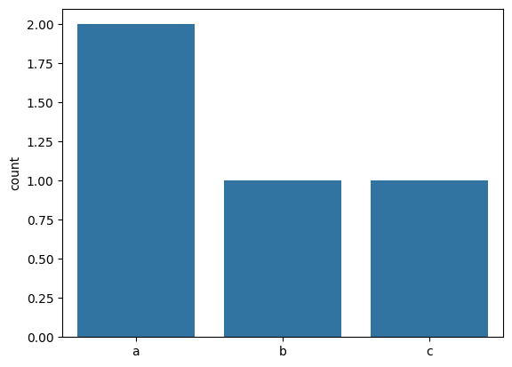

```python
import seaborn

 var = ['a', 'a', 'b', 'c']
 var
 ['a', 'a', 'b', 'c']

 seaborn.countplot(x = var)
```

```python
# seaborn의 load_dataset()로 titanic 데이터 불러와서 df에 할당

import seaborn as sns

df = sns.load_dataset('titanic')
df
```

|  | survived | pclass | sex | age | sibsp | parch | fare | embarked | class | who | adult_male | deck | embark_town | alive | alone |
| --- | --- | --- | --- | --- | --- | --- | --- | --- | --- | --- | --- | --- | --- | --- | --- |
| 0 | 0 | 3 | male | 22.0 | 1 | 0 | 7.2500 | S | Third | man | True | NaN | Southampton | no | False |
| 1 | 1 | 1 | female | 38.0 | 1 | 0 | 71.2833 | C | First | woman | False | C | Cherbourg | yes | False |
| 2 | 1 | 3 | female | 26.0 | 0 | 0 | 7.9250 | S | Third | woman | False | NaN | Southampton | yes | True |
| 3 | 1 | 1 | female | 35.0 | 1 | 0 | 53.1000 | S | First | woman | False | C | Southampton | yes | False |
| 4 | 0 | 3 | male | 35.0 | 0 | 0 | 8.0500 | S | Third | man | True | NaN | Southampton | no | True |
| ... | ... | ... | ... | ... | ... | ... | ... | ... | ... | ... | ... | ... | ... | ... | ... |
| 886 | 0 | 2 | male | 27.0 | 0 | 0 | 13.0000 | S | Second | man | True | NaN | Southampton | no | True |
| 887 | 1 | 1 | female | 19.0 | 0 | 0 | 30.0000 | S | First | woman | False | B | Southampton | yes | True |
| 888 | 0 | 3 | female | NaN | 1 | 2 | 23.4500 | S | Third | woman | False | NaN | Southampton | no | False |
| 889 | 1 | 1 | male | 26.0 | 0 | 0 | 30.0000 | C | First | man | True | C | Cherbourg | yes | True |
| 890 | 0 | 3 | male | 32.0 | 0 | 0 | 7.7500 | Q | Third | man | True | NaN | Queenstown | no | True |

891 rows × 15 columns

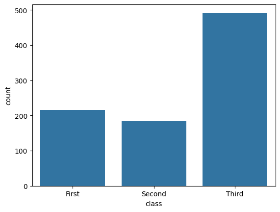

```python
sns.countplot(data = df, x = 'class') # x축 class
```

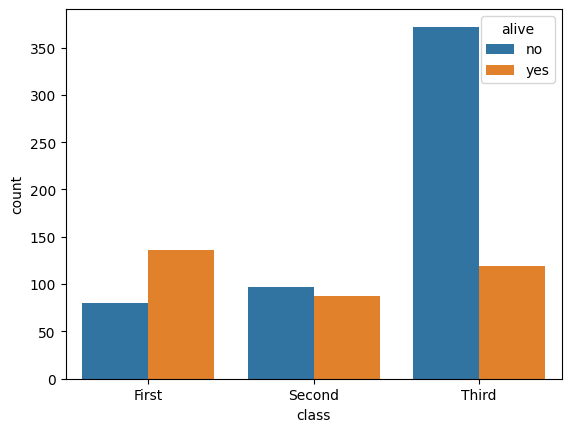

```python
sns.countplot(data = df,  x = 'class', hue = 'alive') # x축 class, alive별 색 표현
```

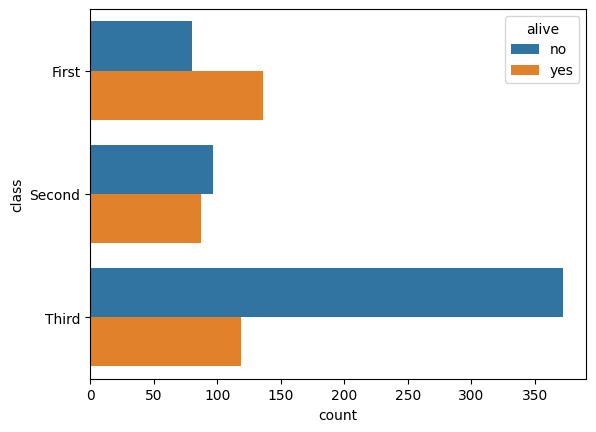

```python
sns.countplot(data = df, y = 'class', hue = 'alive') # y축 class, alive별 색 표현
```

+) 함수 사용 시 파라미터 지정하는 방식 등 문법이 기억나지 않을 땐 -> 함수명 앞 또는 뒤에 물음표를 넣어 Help 함수 실행해서 매뉴얼 출력

```python
sns.countplot?
```

4) 모듈

- 함수가 많은 패키지는 비슷한 함수끼리 몇 개의 모듈로 나뉘어 있음. 패키지라는 큰 꾸러미에 비슷한 함수들끼리 모아둔 작은 꾸러미라고 생각. 패키지 -> 모듈 -> 함수

ex) 머신러닝 모델 만들 때 사용하는 sklearn 패키지 안에는 metrics, tree, model_selection 등 여러 모듈이 있다. metrics 모듈에는 머신러닝 모델의 예측이 얼마나 정확한지 성능을 평가할 때 사용하는 accuracy_score() 함수가 있다. accuracy_score()를 사용하려면 먼저 import sklearn.metrics로 패키지를 로드하는 코드 뒤에 점을 찍고 모듈 이름을 입력한다.

import 패키지.모듈 # 패키지의 모듈 로드

패키지.모듈명.함수명() #패키지, 모듈의 함수 사용

```python
import sklearn.metrics
sklearn.metrics.accuracy_score()  # 함수에 아무것도 입력하지 않아서 오류나는 거 당연


# 위의 두 번째 줄 처럼 패키지.모듈.함수 입력 번거로우면
# from 패키지명.모듈명 import 함수명 으로 로드해서 함수만 사용 가능
from sklearn import metrics
metrics.accuracy_score()

from sklearn.metrics import accuracy_score
accuracy_score()
```

[output not shown]

p. 73 혼자서 해보기

1. 시험 점수 변수 만들고 출력하기 학생 5명이 시험을 봤습니다. 학생들의 시험 점수를 담고 있는 변수를 만들어 출력해 보세요. 학생들 의 시험 점수는 다음과 같습니다. 80, 60, 70, 50, 90
2. 합계 점수 구하기 앞 문제에서 만든 변수를 이용해 합계 점수를 구해 보세요
3. 합계 점수 변수 만들어 출력하기 합계 점수를 담고 있는 새 변수를 만들어 출력해 보세요 앞 문제를 풀 때 사용한 코드를 응용하면 됩니다.

```python
score = [80, 60, 70, 50, 90]
score

sum(score)

sum_score = sum(score)
sum_score
```

```
350
```